# Bay Wheels User Trends in 2018

## Investigation Overview

The primary goal of this investigation was looking at the different behaviors and patterns of Bay Wheels users. Bay Wheels, previously Ford GoBike, is a regional public bicycle sharing system in California's San Francisco Bay Area. The main focus was on the start timestamp (Time, Day & Month), figuring out the peak times when bikes are high in demand as well as off-peak times.

## Dataset Overview

The data consisted information about individual approximately 1,860,000 trips made in a bike-sharing system covering the greater San Francisco Bay area in 2018. The attributes included start time, trip duration, user type as well as additional measurements such as gender and birth date. 147,414 data points were removed from the analysis due to missing information and validity issues.

```python
# import all packages and set plots to be embedded inline
import numpy as np
import pandas as pd
import matplotlib.pyplot as plt
import seaborn as sb

%matplotlib inline

# suppress warnings from final output
import warnings
warnings.simplefilter("ignore")
```

```python
# load in the dataset into a pandas dataframe
trips = pd.read_csv('clean_dataset.csv')
```

```python
# convert day, month into ordered categorical types
ordinal_var_dict = {'day': ['Monday', 'Tuesday', 'Wednesday', 'Thursday', 'Friday', 'Saturday', 'Sunday'],
                    'month': ['Jan', 'Feb', 'Mar', 'Apr', 'May', 'Jun', 'Jul', 'Aug', 'Sep', 'Oct','Nov', 'Dec']}

for var in ordinal_var_dict:
    ordered_var = pd.api.types.CategoricalDtype(ordered = True, categories = ordinal_var_dict[var])
    trips[var] = trips[var].astype(ordered_var)
```

## User Types

As defined on the Bay [Wheels Website](https://www.lyft.com/bikes/bay-wheels/system-data), “Subscriber” are Member of Bay Wheels whereas “Customer” are casual users. In 2018, Subscribers contributed with the majority of trips making around 88.4%. The remaining 11.6% trips were related to customers.

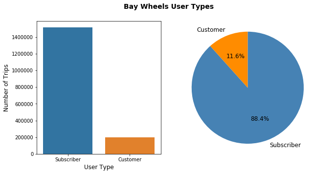

```python
plt.figure(figsize = [10, 5])
plt.suptitle('Bay Wheels User Types', fontsize=14, fontweight='demi')

#user type pie chart
plt.subplot(1, 2, 1)
sb.countplot(data = trips, x = 'user_type')
plt.xlabel('User Type', fontsize=12)
plt.xticks(fontsize=10)
plt.ylabel('Number of Trips', fontsize=12)
plt.yticks(fontsize=10);

#user type bar chart
plt.subplot(1, 2, 2)
sorted_counts = trips['user_type'].value_counts()
colors = ['steelblue', 'darkorange']
plt.pie(sorted_counts, labels = sorted_counts.index, startangle = 90, counterclock = False, autopct='%1.1f%%',
        colors = colors, textprops={'fontsize': 12})
plt.axis('square');
```

## Average Weekly Trip Duration By User Type

The average trip duration for Customers is longer than that of Subscribers throughout the whole week. Subscibers have a relatively unchanging trip durations which might be due to work/school schedules but it increases during the weekend. For Customers, their average trip duration drastically jumps on Saturday. In general for both user types, trips are shorter during weekdays and longer during weekends.

```python
# select trips without the 1% outlier to prevent visualization distortion
mask = trips['duration_min'] <= 65
without_outliers = trips[mask]
```

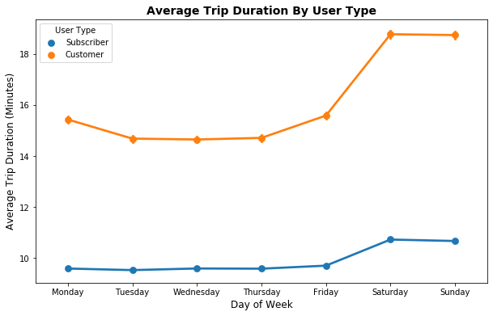

```python
#plotting the graph
plt.figure(figsize=(10,6))
sb.pointplot(x = 'day', y = 'duration_min', hue='user_type', data = without_outliers)
plt.xlabel('Day of Week',fontsize=12)
plt.xticks(fontsize=10)
plt.ylabel('Average Trip Duration (Minutes)',fontsize=12)
plt.yticks(fontsize=10)
plt.legend(title = 'User Type')

plt.title('Average Trip Duration By User Type', fontsize=14, fontweight='demi');
```

## Hourly Trend during Weekdays By User Type

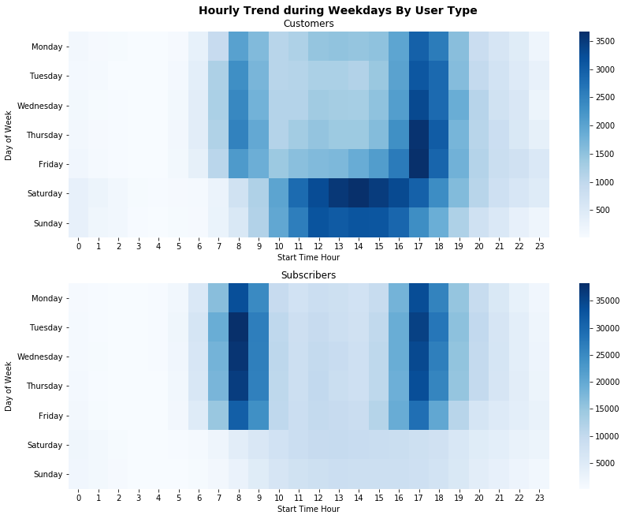

```python
plt.figure(figsize=(12,9))

#summarize the customer counts
customer_counts = trips.query('user_type == "Customer"').groupby(["day","hour"]).agg({'bike_id': 'count'}).reset_index()
customer_counts = customer_counts.pivot(index = 'day', columns = 'hour', values = 'bike_id')

# Top plot: customer heatmap
plt.subplot(2, 1, 1)
sb.heatmap(customer_counts, cmap = 'Blues')
plt.tight_layout()
plt.title('Customers')
plt.xlabel('Start Time Hour')
plt.ylabel('Day of Week')
plt.tight_layout();

#summarize the subscriber counts
subscriber_counts = trips.query('user_type == "Subscriber"').groupby(["day","hour"]).agg({'bike_id': 'count'}).reset_index()
subscriber_counts = subscriber_counts.pivot(index = 'day', columns = 'hour', values = 'bike_id')

# Bottom plot: Subscriber heatmap
plt.subplot(2, 1, 2)

#plotting the heatmap
sb.heatmap(subscriber_counts, cmap = 'Blues')
plt.title('Subscribers')
plt.xlabel('Start Time Hour')
plt.ylabel('Day of Week')
plt.tight_layout();
plt.suptitle('Hourly Trend during Weekdays By User Type', fontsize=14, fontweight='demi', y=1.01);
```

## Monthly Trend Line By User Types

It does not come as a surprise that both Customers and Subscribers tend to use the bike service during early-mid autumn and summer months. During winter months, the demand was quite low which is quite expected given the freezing cold weather. Januaray is considered to be the coldest month in San Francisco [Reference Link](https://www.weather-us.com/en/california-usa/san-francisco-climate).  
The number of trips by subscribers significantly increased during May as well as October and drastically dropped starting November. For customers, the peak month has been July. Unlike subscribers, their number of trips decreased during October.

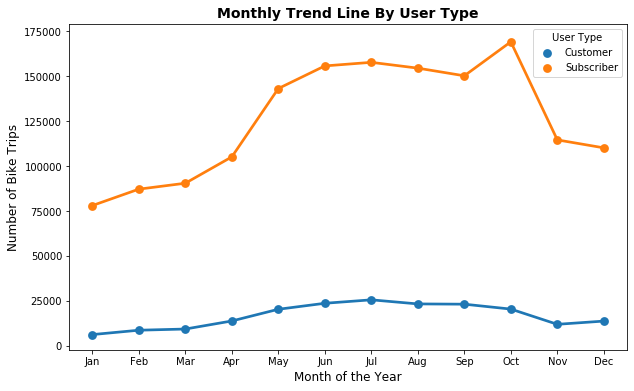

```python
#aggregating the data
user_month = trips.groupby(['month', 'user_type']).agg({'bike_id': 'count'}).reset_index()

#plotting the trend line
plt.figure(figsize=(10,6))
sb.pointplot(x = 'month', y = 'bike_id', data = user_month, hue='user_type')
plt.xlabel('Month of the Year',fontsize=12)
plt.xticks(fontsize=10)
plt.ylabel('Number of Bike Trips',fontsize=12)
plt.yticks(fontsize=10)
plt.legend(title = 'User Type')

plt.title('Monthly Trend Line By User Type', fontsize=14, fontweight='demi');
```

## Extra: Monthly Trend Line By Age Groups

At the beginning of 2018, the 30-40 age group had the highest number of trips. It remained occupying the highest monthly trip count up until June. This is when the turning point happened, the 18-30 age group took the lead and kept it until the end of the year. The 18-30 age group has been increasing month by month from Jan till May with almost the same numbers as the 30-40 age group but what suddenly happened during June?

```python
#create age bins
trips['age_bins'] = pd.cut(x=trips['member_age'], bins=[18, 30, 40, 50, 60])
trips['age_bins'].value_counts()

#renaming the bin labels
trips['age_bins']=pd.cut(trips.member_age,bins = [18, 30, 40, 50, 60],labels=['18 - 30', '30 - 40', '40 - 50', '50 - 60'])
```

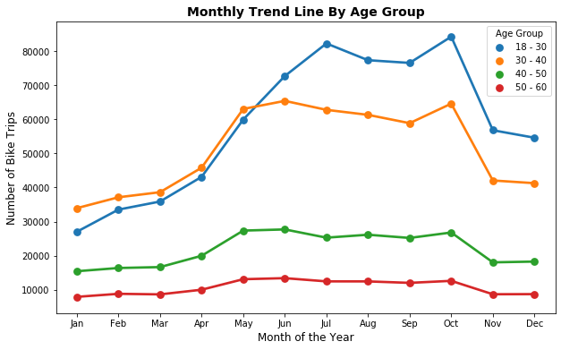

```python
#aggregating the data
age_month = trips.groupby(['month', 'age_bins']).agg({'bike_id': 'count'}).reset_index()

#plotting the trend line
plt.figure(figsize=(10,6))
sb.pointplot(x = 'month', y = 'bike_id', data = age_month, hue='age_bins')
plt.xlabel('Month of the Year',fontsize=12)
plt.xticks(fontsize=10)
plt.ylabel('Number of Bike Trips',fontsize=12)
plt.yticks(fontsize=10)
plt.legend(title = 'Age Group')

plt.title('Monthly Trend Line By Age Group', fontsize=14, fontweight='demi');
```